# Modeling the persistence of plant populations in fragmented ecosystems - ScienceDirect

## Cited By (1)

## Figures (6)

[figure not shown]

[figure not shown]

[figure not shown]

[figure not shown]

[figure not shown]

[figure not shown]

## [Ecological Modelling](https://www.sciencedirect.com/journal/ecological-modelling)

[Volume 457](https://www.sciencedirect.com/journal/ecological-modelling/vol/457/suppl/C), 1 October 2021, 109681

# Modeling the persistence of plant populations in fragmented ecosystems

https://doi.org/10.1016/j.ecolmodel.2021.109681[Get rights and content](https://s100.copyright.com/AppDispatchServlet?publisherName=ELS&contentID=S0304380021002398&orderBeanReset=true)

## Highlights

**•**

Develop model for effect of area on plant growth.

**•**

Establish recruitment and death rates.

**•**

Fit parameters for Heliconia acuminata.

**•**

Find minimum area for survival.

**•**

Compare with linear matrix demographic models.

## Abstract

Ecosystem fragmentation is one of the main threats to species persistence via habitat reduction and isolation which often lead to species extinctions. A question that has long been of interest is the minimum habitat size that can sustain viable populations in fragmented landscape. Despite numerous empirical and theoretical efforts on this topic, most studies fail to address this central question, and our mechanistic understanding of and capacity to predict the effects and outcomes associated with fragmentation stressor is still illusive. We develop an ordinary differential equation (ODE) based framework that incorporates the effect of the patch area on the net population growth rate for a [plant species](https://www.sciencedirect.com/topics/earth-and-planetary-sciences/plant-specie) in fragmented ecosystem via a general net growth function. We investigate the minimum patch area needed to sustain a given plant species. We use data from the Amazonian herb *[Heliconia](https://www.sciencedirect.com/topics/agricultural-and-biological-sciences/heliconia)* *acuminata* to test our model. Furthermore, we compare the performance ODE model and a linear matrix model to predict the observed data. We provide a general formula for a threshold value for the fragment area, below which a plant population is not viable. For *Heliconia acuminata*, our ODE-based model predicts a value for the minimum fragment area of $≈0.7ha$, which reflects the observed data and is smaller than the value obtained using the matrix projection model. Our findings suggest that the *Heliconia’s* mortality rate responds more negatively to fragmentation. Furthermore, we found that the ODE-based model can serve as an alternative to the linear demographic model.

## Keywords

Forest fragmentation

ODE models

Linear matrix models

Population dynamics

Amazonian herb

Minimum fragment size

## 1. Introduction

The rate of species extinction and [ecosystems degradation](https://www.sciencedirect.com/topics/earth-and-planetary-sciences/ecosystem-degradation) is increasing worldwide due to increasing chronic anthropogenic disturbances and of human population growth. [Forest fragmentation](https://www.sciencedirect.com/topics/agricultural-and-biological-sciences/forest-fragmentation) and associated habitat loss and isolation are important causes of known species extinctions and one of the main threats to species persistence (Andreazzi et al., 2012, Broadhurst et al., 2008, Bruna, 2003, Brudvig et al., 2015, Flaspohler et al., 2010, Gagnon et al., 2011, Jacquemyn et al., 2012, Kolb et al., 2010, Laurance et al., 2011, Tang et al., 2011, Vaughn et al., 2014, Zambrano and Salguero-Gómez, 2014). Habitat patchiness, including fragmentation, has been an important concept in ecology for over 80 years. For example, early work on the importance of habitat heterogeneity by Gause (1934) suggests that persistence of predator–prey systems depends on the availability of separate refuges for prey. Also, there is empirical evidence that reduction in habitat size has long lasting effect on population dynamics as well as community assembly and associated dynamics (Bruna, 2003, Gagnon et al., 2011, Kolb et al., 2010, Zambrano and Salguero-Gómez, 2014, Bruna and Kress, 2002, Fahrig, 2017, Matesanz et al., 2017, Rybicki et al., 2020, Lucas, 2020). Most of these studies used linear matrix models (Bolker et al., 2009, Caswell, 2001, Cushing, 1998, Morris and Doak, 2003) based on field data to project population dynamics response to habitat reduction.

Quoting (Bruna, 2003), “Matrix-based demographic models have become increasingly common in ecology because of their application from life-history evolution to conservation and there is a broad body of literature describing their construction, interpretation, assumptions, and limitations”. Linear matrix models can consider the dependence of the birth or death rate on the population density but studies including such dependence are not found often in the literature (Silva Matos et al., 1999). However, several works demonstrate the existence of such density dependent processes as well as its role in determining plant population persistence in fragmented landscapes (Broadhurst et al., 2008, Jacquemyn et al., 2012, Bruna and Kress, 2002, Jacquemyn et al., 2003, Pachepsky and Levine, 2011, Lienert, 2004). Furthermore, fragmentation studies that used these linear matrix models failed to predict the system responses beyond observed degree of fragmentation and often neglect the role of path isolation. Consequently, predicting how fragmentation stressor impacts the plant population viability is still illusive (Andreazzi et al., 2012, Rybicki et al., 2020, Lucas, 2020, Didham et al., 2012).

Mathematical modeling with data integration is an important tool to obtain insights to many aspects of ecosystem [sustainability](https://www.sciencedirect.com/topics/earth-and-planetary-sciences/environmental-impact-assessment) and management. There exists a substantial body of theoretical studies focusing on modeling the spread of one population in fragmented ecosystems (Brudvig et al., 2015, Cantrell et al., 2011, Cantrell and Cosner, 2003, Ferrari et al., 2014, Hastings et al., 2004, Musgrave and Lutscher, 2014, Murray, 2002, Neubert and Parker, 2004, Williamson, 1989). These range from ordinary differential equations based models of meta-populations in patches to network models to models based on [reaction diffusion equations](https://www.sciencedirect.com/topics/earth-and-planetary-sciences/reaction-diffusion-equation) to structural equation models (SEM). These theoretical models aid to understand the influence of forest fragmentation beyond the limits of observed fragmentation examples. This is critical given that replicated cases of forest fragmentation are often scarce, and in some cases experimentally manipulated (Laurance et al., 2011) due to lack of study examples. However, most of these theoretical studies often do not provide practical answers to the key question of the minimum or optimal fragment size that is needed to protect the populations in fragmented ecosystem.

To further our mechanistic understanding of theoretical and practical conservation implications of forest fragmentation on species extinction, it is critical to develop a modeling framework that addresses these issues. We propose a model that uses the flexibility of existing theoretical models on fragmentation by the practical use of linear matrix models to illustrate how to investigate the minimum fragment size necessary to maintain viable population. The model consists of a single ordinary differential equation (ODE) and explicitly incorporates a density dependency on the net growth rate (recruitment rate minus death rate) of the species population. The multiple mechanisms by which fragmentation affects the recruitment rate is a complex topic to disentangle. It has been largely investigated by a couple of researchers (see Bruna, 2003, Brudvig et al., 2015, Jacquemyn et al., 2012, Lienert, 2004, Bruna et al., 2004, Cramer et al., 2007 references there in) but it remains elusive. Although it is critical to understand such mechanisms, we do not address it in this paper. Instead we assume that plant growth is dependent on population density (or biomass density) and is modeled by a logistic type function. This particular form was chosen because a logistic growth rate is one of the most common and simplest assumption in population models (see Allen, 2007.).

Furthermore, we assume that population net growth rate is affected by the reduction of patch area through a general net growth function. This assumption reflects the knowledge in the field that patch size affects some vital rates via edge effects. How these interact to influence the asymptotic growth rate of a population is poorly understood. For instance, Bruna and Oli (Bruna and Oli, 2005) found at least one year where the asymptotic growth rate of the *[Heliconia](https://www.sciencedirect.com/topics/agricultural-and-biological-sciences/heliconia)* population was very similar in the fragmented patches and the continuous forest.

The model is used to broadly address the question: What is the minimum patch area needed to sustain any plant population? To provide a practical example, we specifically use the model to determine the minimum patch size necessary to sustain the populations of *Heliconia acuminata* (Heliconiaceae) in a fragmented landscape. This Amazonian understory herb is about 30–50 cm tall with a maximum size of about 1.6 m and native to the South American countries namely Brazil, Bolivia, Colombia, French Guiana, Guyana, Peru, Suriname, and Venezuela. We parameterized our ODE model by fitting the net population growth rate function using the data sets in Bruna (2003). These data sets were collected in Central Amazonia, in the scope of the Brazil’s Biological Dynamics of Forest Fragments Project — BDFFP. This project is one of the largest and longest experimental data collection endeavors to study the ecological impact of habitat fragmentation (Laurance et al., 2011). The experimental sites consist of fragments of size 1, 10 hectares, and a continuous forest located in Brazil. The [demography and population](https://www.sciencedirect.com/topics/earth-and-planetary-sciences/demography-and-population) dynamics of *Heliconia acuminata* in these patches has been previously studied (Bruna, 2003) using a linear matrix model.

In this paper, we first introduce in Section 2 the mathematical model and its underlying assumptions. We further describe the data sets and present the net population growth rate as well as death rate functions and their parameterization in Section 3. In Section 4, we characterize the dynamics of the model and the biological implications of the findings. Specifically, we provide the formula to compute the area threshold and the specific value for the Amazonia herb in the fragmented system. Although, the goal of the work by Bruna (2003) was not to predict short term changes in abundance, we have used it to compare the result obtained from the matrix project model with the results of our ODE model. In Section 5 we investigate the ability of the ODE model to predict the observed population density of *Heliconia acuminata* in the year 2000 in the Amazonia system studied in Bruna (2003). Fig. 1 shows the conceptual diagram summarizing the development of the model.

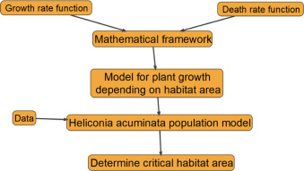

Fig. 1. Conceptual diagram of the mathematical model.

## 2. Mathematical model for fragmented ecosystem

In this section we develop a mathematical model that will integrating experimental data from sites with distinct areas. The model is then used to investigate how fragmentation affects the dynamics of *[Heliconia](https://www.sciencedirect.com/topics/agricultural-and-biological-sciences/heliconia)* *acuminata* population. Let $b(t)$ represent the plant density (or density of biomass), express in number of plants per area (or units of mass per area), in a fragment of a given area and with carrying capacity $K$. The temporal dynamics of the population density is modeled by the following ODE with a logistic growth: (1)$dbdt=β(A)b1−bK=r(A)−μ(A)b1−bK$where $β(A)=r(A)−μ(A)$ is the net growth rate of the population, $r(A)$ is the recruitment rate and $μ(A)$ is the natural death rate of the population.

With model (1) we make the following assumption:

**A.1**

The net growth rate $β(A)$ is assumed to depend on fragment size. The specific form of the function $β(A)$ and its fitting details are given in Section 3.

**A.2**

In Bruna (2003) the size of the continuous forest was not specified. In this paper, we arbitrarily assume that a patch of 100 hectares behaves almost like a continuous forest.

**A.3**

It is reasonable to expect that there may be large variation in the carrying capacity of each site. However, due to lack of detailed data we assume that the carrying capacity of each site is the carrying capacity of the site with the largest area. That is, we assume that the carrying capacity is equal for all sites. Its value is taken to be the average of the observed value of the density for the continuous forest in the year 1999 given in Bruna (2003).

**A.4**

We assume that the patches are completely isolate, that is, there are no dispersal in or out of patches. This is a critical aspect of this species’ biology as shown in Bruna (2003). In particular, the study shows that, even though patches are not completely isolated, the interactions between the species in the same patch are much stronger than those between different patches.

**A.5**

There are no seed bank. That is, there are no seeds that are stored in the soil that survives for the next life cycles. This assumption is consistent with the fact that seeds of tropical plants move quickly into a “seedling bank” to escape intense pressure from [seed predators](https://www.sciencedirect.com/topics/agricultural-and-biological-sciences/granivore) and pathogens (Bruna, 2002).

**A.6**

There is no significant vital-death correlation. This means that the probability of dying is not strongly correlated with the reproduction rate. So it can be assumed that the reproduction and death rates are independent of each other. This assumption is reasonable for *Heliconia acuminata* based on discussions in Bruna and Kress (2002).

**A.7**

The death rate $μ$ is assumed to depend on the area. The particular form of the function $μ(A)$ and the details of its parameterization is given in Section 3.

**A.8**

The growth of the population density is logistic.

## 3. Model parameterization

### 3.1. Data description

The data we use consists of three years of census data from 13 populations of the Amazonian understory herb *Heliconia acuminata* in fragments with three distinct areas at Biological Dynamics of [Forest Fragment](https://www.sciencedirect.com/topics/agricultural-and-biological-sciences/forest-fragmentation) Project, located 80 km north of Manaus, Brazil (see Bruna, 2003 for details on methods and results). The data was collected in four sites with area of $1ha$, three sites with area of $10ha$, and six sites in the continuous forest, which in this paper we consider to have an area of $100ha$, (see Appendix A.1).

For each of the sites, Bruna (2003) provided the projected (or asymptotic) population growth rate values for 1998–1999 and 1999–2000 transition years. These values are the dominant [eigenvalue](https://www.sciencedirect.com/topics/earth-and-planetary-sciences/eigenvectors) of each corresponding transition matrix. We called them the projected $λ$ values and denote them by $λp$. Furthermore, we denote by $λpi$ the different values of the projected $λ$ values corresponding to the two transition years, 1998–1999 and 1999–2000, and fragments with three distinct areas. The transition matrices corresponding to years 1998–1999 and 1999–2000 are also given in Bruna (2003).

Additionally, Bruna (2003) gave the values of the observed asymptotic population growth rate for each transition year 1998–1999 and 1999–2000 for each site with distinct areas. These values were computed in Bruna (2003) by dividing the observed plant density at year $t$ by the observed plant density at year $t−1$. In this paper we call them observed $λ$ and denote them by $λoi$. Thus, we have two sets of data points ($λ$, fragment area): a data set consisting of projected values of $λ$ denoted by $(λpi,Ai)$ and a data set consisting of observed $λ$ denoted by $(λoi,Ai)$.

The plant mortality rate for each fragment was computed from the survival probability in the transition matrices and is listed in Appendix A.1.

The values of the population density available correspond to the year 1999. The methodology for computing the values of the density in 1998 and 2000 at each site is given in Appendix A.1. For each year 1998, 1999, and 2000, we obtained two values of plant density. The first set of values are derived from the projected $λp$, which we denote by $(bpi,ti)$ where $i=1,2,3$ corresponds to years $t1=1998,t2=1999$, and $t3=2000$. The second set of values are derived from the observed $λo$, denoted by $(boi,ti)$. A summary of the data used in this paper and a brief description on how it was adapted from the data published in Bruna (2003) is presented in Appendix A.1.

Next, we estimate the parameters for the function $β(A)$ (in Section 3.2) and $μ(A)$ (in Section 3.3). To accomplish this task we use function cftoolin MATLAB – 9.5.0.1049112 (R2018b) to fit the functions to the data just described: $(λpi,ti)$ and $(λoi,ti)$. The best-fit curve is assumed to be that which minimizes the sum of squared residuals. Since the functions are nonlinear, we use the standard error of the regression to assess the goodness-of-fit.

### 3.2. Dependence of $β$ on $A,β(A)$

To establish the function $β(A)$ that will be parameterized with the data, we assume that it satisfies the following properties: **(i)** $β(A)$ is a continuous and differentiable function on $[0,∞)$; **(ii)** when the area of the site is close to zero the growth rate approaches $−∞$. This models the fact that when the area of the patch is very small the biomass or population density decreases very fast. **(iii)** When the area is very large the growth rate levels out at a certain value. Two possible functions that satisfy conditions (i)–(iii) are given in Eqs. (2), (3): (2)$β(A)=ln(λ(A))=βFA−AcA.$and (3)$β(A)=ln(λ(A))=lnc1A1+c2A=lnc1∕c2A1∕c2+A,$Note that the available data contains the values of $λ$, however, we need to estimate $β$. The relation between $λ$ and $β$ is (4)$β(A)=lnλ(A).$Eq. (4) explains why the logarithm appears on both equation (2), (3). The parameter $Ac≥0$ in Eq. (2) is the critical value of the area for which the sign of the net growth rate changes from a negative value to a positive value. We call this point *the switching point*. This is the point at which the plant density switches from increasing to decreasing or vice-versa and we will show this fact in Section 4.

Next we proceed with the estimation of the parameters in the functions. We divide the fitting into two cases. In one case, we use the values of the projected $λ$ for the years 1998–1999 and 1999–2000 across the plots of same size and the corresponding areas, that is, we use the data set $(λpi,Ai)$. In the other case, we utilize the values of the observed $λ$ for the years 1998–1999 and 1999–2000 across the plots of same size and the corresponding areas. This is the data set $(λoi,Ai)$. The values of the data sets are given in Tables A.1 and A.2, Appendix A.1. For each data set we parametrize both functions given in equations (2), (3). There are two parameters to be estimated in each formula, $βF,Ac$ in Eq. (2) and $c1,c2$ in Eq. (3). For each data set and each of the functions we follow two approaches. In one approach, we fix one parameter and estimate the other. In the other approach, we estimate both parameters. When fixing one parameter we choose to fix $βF=lnc1∕c2=lnλF$ because it can be estimated from the available data. It is estimated by averaging over all values of the asymptotic growth rate ($λ$) of the continuous forest (sites with area equal to $100ha$) presented in Appendix A.1. Then compute the natural logarithm of the resulting value. The values for the estimate of $βF$ using the two data sets $(λpi,Ai)$ and $(λoi,Ai)$ are given in Table A.1, Appendix A.1, where they are denoted by $βFp$ and $βFo$, respectively. In particular, when performing the fitting with the data set $(λpi,Ai)$ and fixing one parameter, we set (5)$lnc1∕c2=βF=lnλF≈0.0214.$Then, we estimate the parameter $Ac$ by parametrizing the function in Eq. (2) and estimate $c2$ by fitting the function in Eq. (3). When using the data values $(λoi,Ai)$ we proceed similarly but equation (5) is replaced by (6)$lnc1∕c2=βF=lnλF≈0.1066$

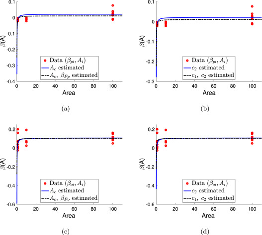

Fig. 2. Fitting results for $β(A)$ functions with the area expressed in $ha$ and $β$ in year$−1$. (a) using projected data $(λpi,Ai)$ and Eq. (2). The curve depicted with black dashed line is obtained when both parameters, $Ac$ and $βF$, are estimated with Matlab cftool. The solid blue line is the fitted curve with $βF=0.0214$ fixed and the value of $Ac$ estimated via cftool. (b) using projected data $(λpi,Ai)$ and Eq. (3). The curve represented with solid blue line is the fitted curve with $βF=ln(c1∕c2)=0.0214$ and the value of $c2$ estimated via cftool. The black dashed line curve is the fitted curve when both $c1$ and $c2$ are estimated with cftool package. (c) and (d) graphs similar to (a) and (b), respectively but using observed data $(λoi,Ai)$ instead of projected data.

The results of the both fittings are summarized in Table 1 and in Fig. 2.

**Results summary:** We found a significant correlation between fragment area and growth rate $β$. Thus, validating our assumption **A.1**, the growth rate is dependent on the area (A), that is $β=β(A)$. Furthermore, when using the data points $(λpi,Ai)$, the Fit Standard Error (RMSE) is approximately the same (either $≈0.021$ or $≈0.022$) across the four fittings (see column 5 in Table 1). Similarly, when using the data points $(λoi,Ai)$, it follows that the RMSE across the four fittings is either 0.065 or 0.066 (see column 7 in Table 1). This result suggests that there is no significant difference in the goodness-of-fit associated to the fitting of the two distinct function forms given in Eqs. (2), (3). This feature is also visible in Fig. 2.

Table 1. Parameters values and the corresponding Fit Standard Error (RMSE ) when fitting function $β(A).$ When the value of $βF$ is not estimated, either using the function presented in Eq. (2) or equation (3), the values of $βF$ projected and $βF$ observed are taken to be 0.0214 and $0.1066,$ respectively (see Eqs. (5), (6).).

| Function Empty Cell | Par. Empty Cell | Unit Empty Cell | With $λp$ projected Value | With $λp$ projected $RMSE$ | with $λo$ observed Value | with $λo$ observed $RMSE$ |
| --- | --- | --- | --- | --- | --- | --- |
| (2) | $Ac$ | ha | 1.753 | 0.02178 | 0.6547 | 0.06573 |
|  | $βF$ fixed |  |  |  | . |  |
|  | $Ac$ | ha | 2.406 | 0.02062 | 0.3706 | 0.06496 |
| Empty Cell | $βF$ | year<sup>−1</sup> | 0.01088 |  | 0.1032 |  |
| (3) | $c2$ | ha<sup>−1</sup> | 28.5 | 0.02184 | 13.84 | 0.06573 |
|  | $c1$ fixed |  |  |  | . |  |
|  | $c1$ | (year×ha)<sup>−1</sup> | 38.02 | 0.02061 | 28.39 | 0.06496 |
| Empty Cell | $c2$ | ha<sup>−1</sup> | 37.61 |  | 25.60 |  |

Based on these results, we select the function in Eq. (2) to model the dependence of $β$ on the area of the fragment. This function is fed into model (1) leading to two models: one model parameterized by $(λpi,Ai)$, and the other parameterized by $(λoi,Ai)$. In both models, $Ac$ is replaced by the corresponding value estimated via Matlab cftool and given in Table 1. Similarly, to the parameter $βF$ is assigned the corresponding value estimated directly from the data and given in Eqs. (5), (6).

### 3.3. Dependence of $μ$ on $A,μ(A)$

Observe that the fitting of the mortality function $μ(A)$ is not necessary for parametrizing model (1). However, we present the parameterization of $μ(A)$ to estimate the minimum fragment area at which the plant mortality equals its natural mortality rate, which is assumed to be the average mortality rate observed in the sites with area equal $100ha$ (continuous forest). This quantity is important as it helps in understanding how fragmentation affects plant vital rates.

We assume that the function $μ(A)$ satisfies the following properties: **(i)** $μ(A)$ is continuous and differentiable; **(ii)** $0≤μ≤1$; **(iii)** when the site area is close to zero the death rate approaches $1$. This models the fact that when the area of the patch is very small the death rate is very high. Furthermore, we assume that when the area is very large the mortality rate levels out at a certain value, which is the natural death rate of the plant if there is no fragmentation in the system (continuous forest). One possible function that satisfies these conditions is (7)$μ(A)=(1−μF)exp(−d1A)+μF,$where $μF$ is the natural plant mortality when the site is not fragmented (continuous forest) and $d1$ is the system decay constant. The value of $μF$ is the average of the mortality data values corresponding to sites with area equal to $100ha$, which is the continuous forest. Those values are provided in Appendix A.1, Table A.4 and their average is $μF=0.0336$. In the same table, the values of $μ$ for each plot with area of $1ha,10ha$ can be found. Eq. (7) together with the data is used to estimate the parameter $d1$. The parameterization is carried out, as when fitting $β(A)$, via MATLAB cftool and the results are given in Table 2 as well as in Fig. 3.

Table 2. The estimated value of $d1$ and corresponding Fit Standard Error (RMSE) obtained when fitting function $μ(A)$ in Eq. (7).

| Par. | Value | Unit | $RMSE$ |
| --- | --- | --- | --- |
| $d1$ | 2.488 | (ha)<sup>−1</sup> | 0.1022 |

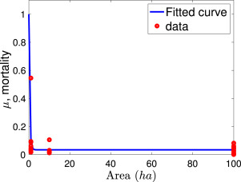

## 4. Effect of fragment size on herb population density

As discussed in Section 3.2, we adopt the function in Eq. (2) to describe the relation between net growth rate $β$ and area. That is, $β(A)=βFA−AcA$. Thus, the model given in Eq. (1) reduces to (8)$dbdt=β(A)b1−bK=βFA−AcAb1−bK$with $β(A)=r(A)−μ(A)$.

The equilibrium states of the system are obtained by solving the equation resulting from setting the right-hand side of (8) equal to zero. Simple calculations shows that, for fixed value of area $A$, the solutions are: (9)$β(A)=βFA−AcA=0,b=0,b=K.$The condition $β(A)=βFA−AcA=0$ holds true when $A=Ac$. At this value of area $β(A)=r(A)−μ(A)=0$. That is, the recruitment rate $r$ and the dead rate $μ$ are equal. Thus, the initial density of biomass does not grow or decay. The system will stabilize at the initial value of the plant density.

We next consider the case $β(A)≠0$ and study the local stability of the equilibrium states $b=0$ and $b=K$. We first compute the Jacobian matrix of the system, which is given by: (10)$JAm=β(A)1−2bK$At equilibrium, $b=0$, $JAm=β(A)=βFA−AcA$. Since $βF>0$ it follows that $JAm$ is positive if $A>Ac$ and negative if $A<Ac$. Therefore, $b=0$ is a locally asymptotical stable (l.a.s) equilibrium if $A<Ac$ while it is unstable if condition $A>Ac$ holds true.

**Proposition 1**

*Consider the model of forest fragmentation given by* (8)*, where the parameters have nonnegative values. If* $A=Ac$*, the plant density stabilizes at its initial value. If* $A<Ac$ *then the equilibrium* $b=0$ *is l.a.s while the equilibrium* $b=K$ *is unstable. On the other hand, if* $A>Ac$ *then the equilibrium* $b=0$ *is unstable and the* $b=K$ *is l.a.s.*

**Biological implications.** If the fragment size is below the *switching point* $Ac$, the population growth rate $β(A)$ becomes negative indicating decreasing population size towards the equilibrium state $b=0$, which implies that the persistence of the herb, *Heliconia acuminata*, is in jeopardy. If the fragment size is above the critical value $Ac$ then, *Heliconia acuminata* population level stabilizes at the carrying capacity of the system $K$. From the fitting we can see that the average value of the critical patch area $Ac$ is approximately $1.75ha$, based on the projected data $(λpi,Aii)$. And the fragment critical area $Ac$ is estimated to have an average value of approximately 0.655 when the observed data set is used to fit the function. Thus, the *switching point* $Ac$, estimated with observed data $(λoi,Ai)$, is lower (about 63%) than the *switching point* estimated with the data $(λpi,Ai)$. Therefore, our model predictions based on the observed data indicate that the plant population has a higher resilience to fragmentation than the prediction based on the projected data. Recall that the values of $λpi$ in the project data $(λpi,Ai)$, are derived from the linear matrix model. These results are illustrated in Fig. 4. When the fragment size is precisely equal to the threshold value, population size that was initially in the patch does not change, which indicates that the plant can persist in the system whenever the initial population size is different from zero.

The results summarized in Proposition 1 are illustrated in Fig. 4. This figure depicts numerical simulations of the model (1) parameterized with the projected data set $(λpi,Ai)$ as well as numerical simulations of the model parameterized with the data $(λoi,Ai)$.

## 5. Model predictability capabilities

After parametrizing the model (1) with the two data sets (projected data set $(λpi,Ai)$ and observed data $(λoi,Ai)$), we test their predictability against the experimental data consisting of plant population density ($b$ corresponding to years $t1=1998$, $t2=1999$ and $t3=2000$, that is, against the data set $(boi,ti)$ given in Appendix A.1, Table A.2. For a patch of a given area, the initial condition used to run the models, the one parameterized by $(λpi,Ai)$ and the one parameterized by the observed data $(λoi,Ai)$, is the average value of the observed population density in year $1998$. More precisely, we used the initial value of $194,342,388$ when the area was fixed at $1ha$, $10ha$, and $100ha$, respectively. The results are shown in Fig. 5.

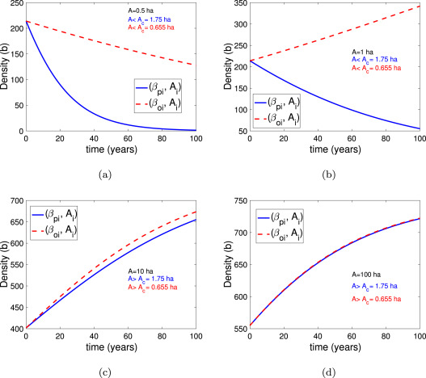

Fig. 4. Numerical simulation of model (1) with the parameterized function (2). The curve depicted with blue solid line is obtained with the value of $βF$, fixed at 0.0214 and the value of $Ac=1.753$, which is estimated with projected data $(λpi,Ai)$. While the curve depicted with red dashed line, the value of $βF$ is fixed at 0.1066 and the value of $Ac=0.6547$ is the one estimated with the observed data $(λoi,Ai)$. The fragment area is $0.5,1,10,100ha(continuous forest)$ in panels (a), (b), (c) and (d), respectively.

Additionally, fixing a patch area, we investigate how well the model parameterized by the set $(λoi,Ai)$ performs to reproduced the average observed data comparatively to the matrix model used in Bruna (2003). Specifically, we compare the temporal pattern obtained with the model parameterized with the observed data set $(λoi,Ai)$, with the observed and projected average plant population density. The results are indicated in Fig. 6.

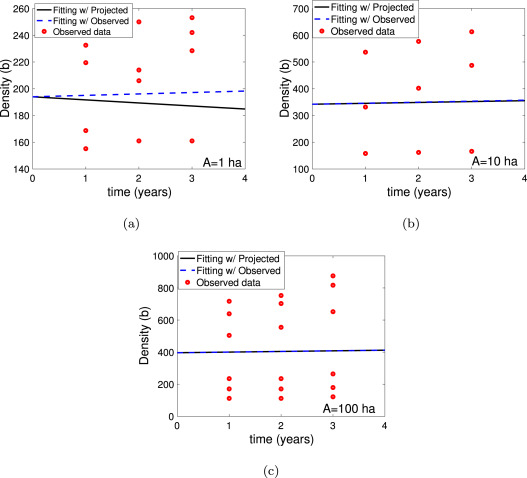

Fig. 5. Simulation of plant density as a function of the patch size $A$ using model (1) parameterized with projected data set $(λpi,Ai)$, shown with black solid line, and observed data set $(λoi,Ai)$, depicted with blue dashed line. The red circle represents the observed data $(boi,ti)$. In the $x$-axis $1,2,3,4$ represent the years $1998,1999,2000,2001$ respectively. (a) Patch size $A=1ha$. (b) Patch size $A=10ha$. (c) Patch size $A=100ha$.

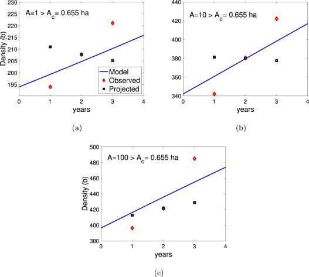

## 6. Discussion of results

Our results are obtained with a model parameterized with the best data set available. The collection of data is in the scope of the Brazil’s Biological Dynamics of Forest Fragments Project — BDFFP. This project is one of the largest and longest experimental work to study the ecological impact of habitat fragmentation (Laurance et al., 2011). It constitutes an incredible effort in the field but there is only three patch sizes in the data and three time instances (1998, 1999, and 2000). This information is far from ideal to parametrize the model. In addition to being small, the data sets exhibit high variability and missing values. Consequently, several approximations were made. For example, there were missing values of projected and observed asymptotic growth rate $λ$ for transitions years 1998–1999 for 3 sites with area $100ha$. So, for these sites, we assume that the density of *Heliconia acuminata* in year 1998 was the same as in the year 1999. The model parameterization can be easily changed to accommodate distinct data sets not only concerning *Heliconia acuminata* that may be produced in the future but also concerning other plant systems.

The results in Fig. 5 suggests that the model, either parameterized by the projected data $(λpi,Ai)$ or parameterized by the observed data $(λoi,Ai)$, do not fit well the plant density observed in each individual site of fragments of same area. This might be due to the constrains of the data sets mentioned above. However, when using the average observed plant density instead of the observed density in each individual site, the model parameterized by the data set $(λoi,Ai)$ captures qualitatively the plant density [temporal evolution](https://www.sciencedirect.com/topics/earth-and-planetary-sciences/temporal-evolution) pattern (see Fig. 6). This occurs for all three distinct areas considered. In contrast, the matrix model predictions only capture the observed temporal evolution of the plant density in the continuous forest (panel c)). Nonetheless, our ODE model fits the observed data slightly better than the linear matrix model.

Due to the fact that the data sets are small it is difficult to conduct robustness test by removing some of the data points and see whether one gets similar fitting results. Sensitivity analysis could be used to gain additional insight on how the model respond to uncertainty in the parameters. This is part of future work.

## 7. Conclusions

We explored the effect of fragmentation on plant population size in an ordinary differential equation (ODE) based framework. This model assume that the growth of the plant population size is of logistic type and that the net growth rate (recruitment rate minus mortality rate) is affected by the reduction of patch area through a general net growth function. We use the model to investigate the minimum patch area needed to sustain any plant/shrub system. Additionally, we parametrize the model with a three years census data of *Heliconia acuminata* in both forest fragments and continuous forest provided in the work by Bruna (2003). We apply the resulting fitted model to determine the minimum fragment size necessary to sustain the *Heliconia acuminata* density in a fragmented landscape. For this specific data set, we also test the hypothesis that the ODE-based model, with the dependence of plant growth rate on the population density explicitly modeled, fits the observed *Heliconia acuminata* density better than the linear matrix demographic models that are common used in the field.

Our theoretical analysis of the model indicates that the persistence of *Heliconia acuminate* is possible when the area of the fragment is higher than a threshold $Ac$, the system *switching point*. That is, for values of the area greater to $Ac$ the net population growth rate is greater than zero which implies persistent plant population whose size will reach (asymptotically) the fragment carrying capacity, if no disturbances occur. The persistence of the plant is still possible if the forest fragment area is equal to $Ac$, but in this case the population stagnates at the initial value.

The *switching point* $Ac$ estimated with the proposed net growth rate function parameterized with the census data from Amazonian *Heliconia acuminata* is $0.655≈1ha$. This result is in agreement with the findings reported by Bruna and Kress (2002), concerning the same Amazonian *Heliconia acuminata* system, which shows that, among the three area patches studied ($1,10,100,ha$), the herb in fragments of $1ha$ is more vulnerable to fragmentation. The *switching point* estimated with same function but parameterized with the data calculated using the asymptotical growth rate $λ$ obtained from the matrix based model and presented in the work by Bruna (2003) is $1.75≈2ha$. Thus, the predictions based on the census data indicate that the plant system is more resilient to fragmentation than the predictions based on the data recovered from the matrix-based model.

Table A.1. Values of the projected $λpi,$ observed $λoi$ asymptotic growth rate, and area of the fragment $Ai$ for each site. The units are: area in ha and $β$ in 1/year.

[output not shown]

The mortality decay constant estimated through the function parameterized with the data census reveals that the mortality rate of *Heliconia acuminata* stabilizes at the value of the mortality rate observed in an ecosystem without fragmentation when the fragment size is greater or equal to $≈4ha$. Thus, our study suggests that, in the particular scenario of *Heliconia acuminata* Amazonian system, the net growth rate is less sensitive to fragmentation than the mortality rate. Such phenomena was also reported for the same plant system (Bruna and Kress, 2002). It was reported that fragments of $10ha$ of land suffered higher mortality than the continuous forest.

Given our results we observed that the ODE-based model presented in this study can serve as an alternative to the linear demographic model since we have included in our ODE model some assumptions about how the mortality and recruitment rates behave which are not included in the linear demographic model. Furthermore, the ODE model is able to fit the given data. This is an interesting result suggesting the use of models that take in account the dependence of the plant population growth rates on population size when investigating the impact of fragmentation on [plant species](https://www.sciencedirect.com/topics/earth-and-planetary-sciences/plant-specie). However, further investigations are needed to verify if this findings are applied to other plant populations in fragmented systems. The model in this paper is very simple. It consists of an ordinary differential equation that represent average or mean field approximations of the true time and spatial scales of the object of study. An alternative formulation could involve an age structured model and/or including spatial component. Additionally, those models could incorporate distinct processes in which fragmentation affects, for example, pollination, [seed dispersal](https://www.sciencedirect.com/topics/earth-and-planetary-sciences/seed-dispersal), the seed and [seedling establishment](https://www.sciencedirect.com/topics/earth-and-planetary-sciences/seedling-establishment). However, any attempt in this direction would require a multitude of parameters and, necessarily, data to validate it. Given the nature of the phenomena at hand, these requirements may be very difficult to satisfy. Therefore, the approach of using simpler models may have advantages over uses of agent based or computational models that are more realistic but providing very limited theoretical insights.

Realistically, we understand that we should consider multi-patch and interactions between the patches; however, since this is an alternative approach to the use of linear demographic model it is important to understand the dynamics of a single isolated patch. In the future we will consider a more realistic model with multi-patches and their connectedness.

Table A.2. Values of the asymptotic growth rates $λpi,λoi,$ area $Ai,$ as well as the observed ($boi$) and projected ($bpi$) values of the population density corresponding to each site in the years 1998, 1999, and 2000. The symbol $∗$ indicates that values of the density were assumed to be equal to the values of density in the year 1999. The units are: area in $ha,$ and density in units of $individuals∕ha.$.

| Area | $bpi$ | $λpi$ | Year | $boi$ | $λoi$ | Area | $bpi$ | $λpi$ | Year | $boi$ | $λoi$ |
| --- | --- | --- | --- | --- | --- | --- | --- | --- | --- | --- | --- |
| 1 | 217.7 | – | 1998 | 219.5 | – | 100 | 732.5 | – | 1998 | 697.6 | – |
| 1 | 157.4 | – | 1998 | 155.2 | – | 100 | 514.4 | – | 1998 | 467.6 | – |
| 1 | 203.3 | – | 1998 | 168.7 | – | 100 | 712.2 | – | 1998 | 647.5 | – |
| 1 | 247 | – | 1998 | 232.6 | – | 100 | 112($∗$) | – | 1998 | 112($∗$) | – |
| 1 | 214 | 0.983 | 1999 | 214 | 0.975 | 100 | 171($∗$) | – | 1998 | 171($∗$) | – |
| 1 | 161 | 0.978 | 1999 | 161 | 1.0375 | 100 | 235($∗$) | – | 1998 | 235 ($∗$) | – |
| 1 | 206 | 0.987 | 1999 | 206 | 1.221 | 100 | 753 | 1.028 | 1999 | 753 | 1.05 |
| 1 | 250 | 0.988 | 1999 | 250 | 1.075 | 100 | 555 | 1.079 | 1999 | 555 | 1.1 |
| 1 | 213.4 | 0.997 | 2000 | 228.4 | 1.0675 | 100 | 703 | 0.987 | 1999 | 703 | 1.1 |
| 1 | 159.1 | 0.988 | 2000 | 161 | 1 | 100 | 112 | – | 1999 | 112 | – |
| 1 | 203.7 | 0.989 | 2000 | 242.0 | 1.175 | 100 | 171 | – | 1999 | 171 | – |
| 1 | 244.5 | 0.978 | 2000 | 253.1 | 1.0125 | 100 | 235 | – | 1999 | 235 | – |
| 10 | 164.0 | – | 1998 | 158.0 | – | 100 | 774.1 | 1.04 | 2000 | 875.4 | 1.1625 |
| 10 | 402.0 | – | 1998 | 331.7 | – | 100 | 598.8 | 1.022 | 2000 | 652.1 | 1.175 |
| 10 | 577.0 | – | 1998 | 536.7 | – | 100 | 693.9 | 0.991 | 2000 | 817.2 | 1.1625 |
| 10 | 162 | 0.988 | 1999 | 162 | 1.025 | 100 | 113.6 | 1.014 | 2000 | 121.8 | 1.0875 |
| 10 | 402 | 0.991 | 1999 | 402 | 1.212 | 100 | 174.1 | 1.018 | 2000 | 179.6 | 1.05 |
| 10 | 577 | 0.999 | 1999 | 577 | 1.075 | 100 | 238.8 | 1.016 | 2000 | 264.4 | 1.125 |
| 10 | 158.4 | 0.978 | 2000 | 166.0 | 1.025 |  |  |  |  |  |  |
| 10 | 399.6 | 0.994 | 2000 | 487.4 | 1.2125 |  |  |  |  |  |  |
| 10 | 574.7 | 0.996 | 2000 | 613.1 | 1.0626 |  |  |  |  |  |  |

## CRediT authorship contribution statement

**Maria C.A. Leite:** Conceptualization, Methodology, Software, Investigation, Data curation, Writing – original draft, Writing – review & editing, Visualization, Supervision, Funding acquisition. **Rebecca Sauchuk:** Software, Visualization. **Folashade B. Agusto:** Conceptualization, Methodology, Software, Formal analysis, Funding acquisition, Writing – original draft, writing – review & editing. **Orou G. Gaoue:** Conceptualization, Resources, Investigation, Data curation. **Benito Chen-Charpentier:** Conceptualization, Methodology, Formal analysis, Investigation, Writing – original draft, Supervision.

## Declaration of Competing Interest

One or more of the authors of this paper have disclosed potential or pertinent conflicts of interest, which may include receipt of payment, either direct or indirect, institutional support, or association with an entity in the biomedical field which may be perceived to have potential conflict of interest with this work. For full disclosure statements refer to https://doi.org/10.1016/j.ecolmodel.2021.109681. Benito Chen-Charpentier reports financial support was provided by Nimbios, Uiversity of Tennessee, Knoxville. Fola Agusto reports financial support was provided by Nimbios, Uiversity of Tennessee, Knoxville. Maria Leite reports financial support was provided by Nimbios, Uiversity of Tennessee, Knoxville. Orou Gaoue reports financial support was provided by Nimbios, Uiversity of Tennessee, Knoxville. Fola Agusto reports financial support was provided by NSF. Maria Leite reports financial support was provided by University of South Florida St. Petersburg.

## Acknowledgments

Leite acknowledges support from USFSP 2019–20 Internal Research Grant, United States that made possible the full support of the undergraduate student R. Sauchuk’s research project. Agusto acknowledges support from NSF, United States under EPSCOR grant number OIA 1656006. The authors are thankful for support from NIMBioS sponsored by NSF, United States Award # DBI – 1300426 and, partially by University of Tennessee, Knoxville, United States . The authors acknowledges Emilio Bruna for useful suggestions. The authors are also thankful to the anonymous reviewers for their valuable comments that essentially improve the paper.

## Appendix.

### A.1. Data preparation

The data was extracted from Bruna (2003). More precisely, the plant density at each site corresponding to year 1999 as well as the fragment area are given in Table 1, (Bruna, 2003). The projected asymptotical growth rate $λ$ corresponding to the transition years $1998−1999$ and $1999−2000$ for each site is also provided in Table 1. The details on the computation of these values are given also in Bruna (2003). The values of observed $λ$ are depicted in Fig. 5 in the same work. The transition matrices describing the dynamics of the *Heliconia acuminata* are provided in Appendix B, (Bruna, 2003).

#### A.1.1. Values of the projected $λpi$, observed $λoi$ asymptotic growth rate, and area $Ai$ of the fragment for each site

The projected values of $λ$ (that is, $λpi$) and area of each fragments/site ($Ai$) were read off Table 1 (Bruna, 2003) and is provided in Table A.1 for completeness. The resulting data set is denoted by $(λpi,Ai)$. The observed transition values of $λoi$ summarized in the Table A.1 were read off Fig. 5 and the data set is denoted by $λoi$. The corresponding values of the growth rate $βpi$ and $βoi$ were computed using the relation $β=ln(λ)$. On the right hand-side of Table A.1 is listed the values of the projected and observed growth rates corresponding to the continuous forest. These values are the average of the values of $βpi$ and $βoi$ for sites with area $100$ ha and they are denoted by $βFp$ and $βFo$, respectively.

#### A.1.2. Values of the population density of *Heliconia acuminata* $bpi$, (projected) and $boi$ (observed) in years $1998,1999$, and $2000$ for each site

The density of the plant in the years $1998,1999$ and $2000$ were computed from the values of the density registered for year $1999$ (Table 1, Bruna, 2003) and using the formula: (A.1)$λ=density of Heliconia in year t+1density of Heliconia in year t.$For each area and each year, we obtain two data sets: projected density ($bpi,ti$) and observed density ($boi,ti$), where the indices $i=1,2,3$ represent years $1998,1999,2000$, respectively. The former set is obtained by using the values $λpi$ in Eq. (A.1). The values of $boi$ in latter set are computed using $λoi$ in the same equation. For the sites with area $100$ ha for which the values of projected and observed $λ$ corresponding to the transition year $1998−1999$ are not available in Bruna (2003), we assumed that the population density in year 1998 is the same as in year 1999. The sets $(bpi,ti$) and $(boi,ti)$ are given in Table A.2. In Table A.3 we present the average values of *Heliconia* density in sites with area $100$ ha (continuous forest) and corresponding to year $1998$.

Table A.3. Average value of the observed plant density and projected herb density in year 1998 corresponding to areas $1,10,100ha$.

Area

Average Observed density

Average Projected density

(ha)

$b$ in 1998 (unit of $individuals∕ha.$)

$b$ in 1998 (units of $individuals∕ha.$)

1

194

206

10

342

381

100

388

413

#### A.1.3. Mortality rates

The mortality rate for each fragment was computed using the survival probability calculated from the transition matrices describing the dynamics of *Heliconia acuminata* provided in Appendix B (Bruna and Kress, 2002). The values presented in Table A.4 are the average of the mortality in years 1999 and 2000.

The value of the natural death rate $μF$ in the continuous forest was computed by averaging over all values of the plant’s mortality in all sites of area $100ha$.

Table A.4. Average values of the plant’s mortality rate $μ$ in each site with units 1/year. $μF$ is the average of the mortality rate in patches of area $100ha.$.

| Area (ha) | Average mortality $μi$ (1/year) | Area (ha) | Average mortality $μi$ (1/year) | $μF$ (1/year) |
| --- | --- | --- | --- | --- |
| 1 | 0.0287 | 100 | 0.0595 |  |
| 1 | 0.017 | 100 | 0.0111 |  |
| 1 | 0.0343 | 100 | 0.0813 |  |
| 1 | 0.545 | 100 | 0.0427 | 0.0336 |
| 1 | 0.0886 | 100 | 0.0289 |  |
| 1 | 0.0932 | 100 | 0.0482 |  |
| 1 | 0.0437 | 100 | 0.0001 |  |
| 1 | 0.0606 | 100 | 0.0248 |  |
| 10 | 0.0186 | 100 | 0.006 |  |
| 10 | 0.0154 |  |  |  |
| 10 | 0.0121 |  |  |  |
| 10 | 0.1052 |  |  |  |
| 10 | 0.0296 |  |  |  |
| 10 | 0.0301 |  |  |  |

## References

**Allen, 2007**

Allen L.J.S.

**An Introduction To Mathematical Biology**

Pearson/Prentice Hall (2007)

[Google Scholar](https://scholar.google.com/scholar_lookup?title=An%20Introduction%20To%20Mathematical%20Biology&publication_year=2007&author=L.J.S.%20Allen)

**Andreazzi et al., 2012**

Andreazzi C.S., Pimenta C.S., Pires A.S., Fernandez F.A.S., Oliveira-Santos L.G., Menezes J.F.S.

**Increased productivity and reduced seed predation favor a large-seeded palm in small atlantic forest fragments**

Biotropica, 44 (2012), pp. 237-245, 10.1111/j.1744-7429.2011.00782.x

[View Record in Scopus](https://www.scopus.com/inward/record.url?eid=2-s2.0-84857691422&partnerID=10&rel=R3.0.0)Google Scholar

**Bolker et al., 2009**

Bolker B., Brooks M., Clark S., Poulsen J., Stevens M., White J.-S.

**Generalized linear mixed models: A practical guide for ecology and evolution**

Trends Ecol. Evol., 24 (2009), pp. 127-135, 10.1016/j.tree.2008.10.008

[Article](https://www.sciencedirect.com/science/article/pii/S0169534709000196)[Download PDF](https://www.sciencedirect.com/science/article/pii/S0169534709000196/pdfft?md5=841e514ab257a0461df759eef08d4598&pid=1-s2.0-S0169534709000196-main.pdf)[View Record in Scopus](https://www.scopus.com/inward/record.url?eid=2-s2.0-60949108998&partnerID=10&rel=R3.0.0)Google Scholar

**Broadhurst et al., 2008**

Broadhurst L.M., Young A.G., Forrester R.

**Genetic and demographic responses of fragmented Acacia dealbata (Mimosaceae) populations in southeastern Australia**

Biol. Cons., 141 (11) (2008), pp. 2843-2856, 10.1016/j.biocon.2008.08.021

URL https://linkinghub.elsevier.com/retrieve/pii/S0006320708003145

[Article](https://www.sciencedirect.com/science/article/pii/S0006320708003145)[Download PDF](https://www.sciencedirect.com/science/article/pii/S0006320708003145/pdfft?md5=bdee40c165bd302c062b92344de5164f&pid=1-s2.0-S0006320708003145-main.pdf)[View Record in Scopus](https://www.scopus.com/inward/record.url?eid=2-s2.0-53649092474&partnerID=10&rel=R3.0.0)[Google Scholar](https://scholar.google.com/scholar?q=Genetic%20and%20demographic%20responses%20of%20fragmented%20Acacia%20dealbata%20%20populations%20in%20southeastern%20Australia)

**Brudvig et al., 2015**

Brudvig L.A., Damschen E.I., Haddad N.M., Levey D.J., Tewksbury J.J.

**The influence of habitat fragmentation on multiple plant–animal interactions and plant reproduction**

Ecology, 96 (10) (2015), pp. 2669-2678, 10.1890/14-2275.1

URL http://doi.wiley.com/10.1890/14-2275.1

[View Record in Scopus](https://www.scopus.com/inward/record.url?eid=2-s2.0-84944145102&partnerID=10&rel=R3.0.0)[Google Scholar](https://scholar.google.com/scholar?q=The%20influence%20of%20habitat%20fragmentation%20on%20multiple%20plantanimal%20interactions%20and%20plant%20reproduction)

**Bruna, 2002**

Bruna E.M.

**Effects of forest fragmentation on heliconia acuminata seedling recruitment in central Amazonia**

Oecologia, 132 (2002), pp. 235-243, 10.1007/s00442-002-0956-y

[View Record in Scopus](https://www.scopus.com/inward/record.url?eid=2-s2.0-0036938118&partnerID=10&rel=R3.0.0)[Google Scholar](https://scholar.google.com/scholar_lookup?title=Effects%20of%20forest%20fragmentation%20on%20heliconia%20acuminata%20seedling%20recruitment%20in%20central%20Amazonia&publication_year=2002&author=E.M.%20Bruna)

**Bruna, 2003**

Bruna E.M.

**Are plant populations in fragmented habitat recruitment limited? Test with an Amazonian herb**

Ecology, 84 (2003), pp. 932-947, 10.1007/s00442-002-0956-y

[View Record in Scopus](https://www.scopus.com/inward/record.url?eid=2-s2.0-0041313833&partnerID=10&rel=R3.0.0)[Google Scholar](https://scholar.google.com/scholar?q=Are%20plant%20populations%20in%20fragmented%20habitat%20recruitment%20limited%20Test%20with%20an%20Amazonian%20herb)

**Bruna and Kress, 2002**

Bruna E.M., Kress W.J.

**Habitat fragmentation and the demographic structure of an Amazonian understory herb (Heliconia acuminata)**

Conserv. Biol., 16 (5) (2002), pp. 1256-1266, 10.1046/j.1523-1739.2002.99494.x

URL http://doi.wiley.com/10.1046/j.1523-1739.2002.99494.x

[View Record in Scopus](https://www.scopus.com/inward/record.url?eid=2-s2.0-0036793022&partnerID=10&rel=R3.0.0)[Google Scholar](https://scholar.google.com/scholar?q=Habitat%20fragmentation%20and%20the%20demographic%20structure%20of%20an%20Amazonian%20understory%20herb)

**Bruna et al., 2004**

Bruna E.M., Kress W.J., Marques F., Silva O.F.d.

**Heliconia acuminata reproductive success is independent of local floral density**

Acta Amaz., 34 (3) (2004), pp. 467-471, 10.1590/S0044-59672004000300012

URL [http://www.scielo.br/scielo.php?script=sci_arttext&pid=S0044-59672004000300012&lng=en&tlng=en](http://www.scielo.br/scielo.php?script=sci_arttext%26pid=S0044-59672004000300012%26lng=en%26tlng=en)

[View Record in Scopus](https://www.scopus.com/inward/record.url?eid=2-s2.0-54349114167&partnerID=10&rel=R3.0.0)Google Scholar

**Bruna and Oli, 2005**

Bruna E.M., Oli M.K.

**Demographic effects of habitat fragmentation on a tropical herb: life-table response experiments**

Ecology, 86 (7) (2005), pp. 1816-1824

[CrossRef](https://doi.org/10.1890/04-1716)[View Record in Scopus](https://www.scopus.com/inward/record.url?eid=2-s2.0-21744457138&partnerID=10&rel=R3.0.0)Google Scholar

**Cantrell and Cosner, 2003**

Cantrell R., Cosner C.

**Spatial Ecology Via Reaction-Diffusion Equations**

(John Wiley & Sons Ltd) (2003)

[Google Scholar](https://scholar.google.com/scholar_lookup?title=Spatial%20Ecology%20Via%20Reaction-Diffusion%20Equations&publication_year=2003&author=R.%20Cantrell&author=C.%20Cosner)

**Cantrell et al., 2011**

Cantrell R.S., Cosner C., Fagan W.F.

**The implications of model formulation when transitioning from spatial to landscape ecology**

Math. Biosci. Eng., 9 (1) (2011), pp. 27-60, 10.3934/mbe.2012.9.27

URL http://www.aimsciences.org/journals/displayArticlesnew.jsp?paperID=6843

[View Record in Scopus](https://www.scopus.com/inward/record.url?eid=2-s2.0-84904265117&partnerID=10&rel=R3.0.0)Google Scholar

**Caswell, 2001**

Caswell H.

**Matrix Population Models: Construction, Analysis, and Interpretation**

(second ed.), Sinauer Associates, Sunderland, Massachusetts (2001)

[Google Scholar](https://scholar.google.com/scholar_lookup?title=Matrix%20Population%20Models%3A%20Construction%2C%20Analysis%2C%20and%20Interpretation&publication_year=2001&author=H.%20Caswell)

**Cramer et al., 2007**

Cramer J.M., Mesquita R.C.G., Bentos T.V., Moser B., Williamson G.B.

**Forest fragmentation reduces seed dispersal of duckeodendron cestroides, a central amazon endemic**

Biotropica, 39 (6) (2007), pp. 709-718, 10.1111/j.1744-7429.2007.00317.x

URL http://doi.wiley.com/10.1111/j.1744-7429.2007.00317.x

[View Record in Scopus](https://www.scopus.com/inward/record.url?eid=2-s2.0-34948853234&partnerID=10&rel=R3.0.0)Google Scholar

**Cushing, 1998**

Cushing J.

**An Introduction To Structured Population Dynamics**

(second ed.), SIAM, Philadelphia (1998)

[Google Scholar](https://scholar.google.com/scholar_lookup?title=An%20Introduction%20To%20Structured%20Population%20Dynamics&publication_year=1998&author=J.%20Cushing)

**Didham et al., 2012**

Didham R.K., Kapos V., Ewers R.M.

**Rethinking the conceptual foundations of habitat fragmentation research**

From the Students of BI454 At Western Oregon University, Habitat Fragmentation and Pollination Dynamics, Plant Ecology (2012)

Google Scholar

**Fahrig, 2017**

Fahrig L.

**Ecological responses to habitat fragmentation per se**

Annu. Rev. Ecol. Evol. Syst., 48 (2017), pp. 1-23, [10.1146/annurev- ecolsys- 110316- 022612](https://doi.org/10.1146/annurev-%20ecolsys-%20110316-%20022612)

[View Record in Scopus](https://www.scopus.com/inward/record.url?eid=2-s2.0-85027324061&partnerID=10&rel=R3.0.0)[Google Scholar](https://scholar.google.com/scholar_lookup?title=Ecological%20responses%20to%20habitat%20fragmentation%20per%20se&publication_year=2017&author=L.%20Fahrig)

**Ferrari et al., 2014**

Ferrari J.R., Preisser E.L., Fitzpatrick M.C.

**Modeling the spread of invasive species using dynamic network models**

Biol. Invasions, 16 (4) (2014), pp. 949-960, 10.1007/s10530-013-0552-6

URL http://link.springer.com/10.1007/s10530-013-0552-6

[View Record in Scopus](https://www.scopus.com/inward/record.url?eid=2-s2.0-84896038817&partnerID=10&rel=R3.0.0)Google Scholar

**Flaspohler et al., 2010**

Flaspohler D.J., Giardina C.P., Asner G.P., Hart P., Price J., Lyons C.K., Castaneda X.

**Long-term effects of fragmentation and fragment properties on bird species richness in Hawaiian forests**

Biol. Cons., 143 (2) (2010), pp. 280-288, 10.1016/j.biocon.2009.10.009

URL http://linkinghub.elsevier.com/retrieve/pii/S0006320709004509

[Article](https://www.sciencedirect.com/science/article/pii/S0006320709004509)[Download PDF](https://www.sciencedirect.com/science/article/pii/S0006320709004509/pdfft?md5=1cb5d008261b3086ffee41ebbe8d67f8&pid=1-s2.0-S0006320709004509-main.pdf)[View Record in Scopus](https://www.scopus.com/inward/record.url?eid=2-s2.0-73649135699&partnerID=10&rel=R3.0.0)Google Scholar

**Gagnon et al., 2011**

Gagnon P.R., Bruna E.M., Rubim P., Darrigo M.R., Littell R.C., Uriarte M., Kress W.J.

**Growth of an understory herb is chronically reduced in Amazonian forest fragments**

Biol. Cons., 144 (2) (2011), pp. 830-835, 10.1016/j.biocon.2010.11.015

URL http://linkinghub.elsevier.com/retrieve/pii/S0006320710004854

[Article](https://www.sciencedirect.com/science/article/pii/S0006320710004854)[Download PDF](https://www.sciencedirect.com/science/article/pii/S0006320710004854/pdfft?md5=916bdf16fd84023bb5203510019873ee&pid=1-s2.0-S0006320710004854-main.pdf)[View Record in Scopus](https://www.scopus.com/inward/record.url?eid=2-s2.0-79451471146&partnerID=10&rel=R3.0.0)Google Scholar

**Gause, 1934**

Gause G.

**Gause GF the Struggle for Existence**

Williams & Wilkins, Baltimore (1934)

[Google Scholar](https://scholar.google.com/scholar_lookup?title=Gause%20GF%20the%20Struggle%20for%20Existence&publication_year=1934&author=G.%20Gause)

**Hastings et al., 2004**

Hastings A., Cuddington K., Davies K.F., Dugaw C.J., Elmendorf S., Freestone A., Harrison S., Holland M., Lambrinos J., Malvadkar U., Melbourne B.A., Moore K., Taylor C., Thomson D.

**The spatial spread of invasions: new developments in theory and evidence: Spatial spread of invasions**

Ecol. Lett., 8 (1) (2004), pp. 91-101, 10.1111/j.1461-0248.2004.00687.x

URL http://doi.wiley.com/10.1111/j.1461-0248.2004.00687.x

Google Scholar

**Jacquemyn et al., 2012**

Jacquemyn H., De Meester L., Jongejans E., Honnay O.

**Evolutionary changes in plant reproductive traits following habitat fragmentation and their consequences for population fitness: Habitat fragmentation and plant trait evolution**

J. Ecol., 100 (1) (2012), pp. 76-87, 10.1111/j.1365-2745.2011.01919.x

URL http://doi.wiley.com/10.1111/j.1365-2745.2011.01919.x

[View Record in Scopus](https://www.scopus.com/inward/record.url?eid=2-s2.0-83455260171&partnerID=10&rel=R3.0.0)Google Scholar

**Jacquemyn et al., 2003**

Jacquemyn H., Rossum F.V., Brys R., Endels P., Hermy M., Triest L., Blust G.D.

**Effects of Agricultural land use and fragmentation on genetic, demography and population persistence of the rare primula vulgaris, and implications for conservation**

Belg. J. Bot., 136 (1) (2003), pp. 5-22

[View Record in Scopus](https://www.scopus.com/inward/record.url?eid=2-s2.0-0141725536&partnerID=10&rel=R3.0.0)Google Scholar

**Kolb et al., 2010**

Kolb A., Dahlgren J.P., Ehrlén J.

**Population size affects vital rates but not population growth rate of a perennial plant**

Ecology, 91 (11) (2010), pp. 3210-3217, 10.1890/09-2207.1

URL http://doi.wiley.com/10.1890/09-2207.1

[View Record in Scopus](https://www.scopus.com/inward/record.url?eid=2-s2.0-78249256093&partnerID=10&rel=R3.0.0)Google Scholar

**Laurance et al., 2011**

Laurance W.F., Camargo J.L., Luizão R.C., Laurance S.G., Pimm S.L., Bruna E.M., Stouffer P.C., Bruce Williamson G., Bení tez Malvido J., Vasconcelos H.L., Van Houtan K.S., Zartman C.E., Boyle S.A., Didham R.K., Andrade A., Lovejoy T.E.

**The fate of Amazonian forest fragments: A 32-year investigation**

Biol. Cons., 144 (1) (2011), pp. 56-67, 10.1016/j.biocon.2010.09.021

URL https://linkinghub.elsevier.com/retrieve/pii/S0006320710004209

[Article](https://www.sciencedirect.com/science/article/pii/S0006320710004209)[Download PDF](https://www.sciencedirect.com/science/article/pii/S0006320710004209/pdfft?md5=105f304be41369774b69f3355386c4c4&pid=1-s2.0-S0006320710004209-main.pdf)[View Record in Scopus](https://www.scopus.com/inward/record.url?eid=2-s2.0-78751567828&partnerID=10&rel=R3.0.0)Google Scholar

**Lienert, 2004**

Lienert J.

**Habitat fragmentation effects on fitness of plant populations – a review**

J. Nat. Conserv., 12 (1) (2004), pp. 53-72, 10.1016/j.jnc.2003.07.002

URL https://linkinghub.elsevier.com/retrieve/pii/S1617138104000068

[Article](https://www.sciencedirect.com/science/article/pii/S1617138104000068)[Download PDF](https://www.sciencedirect.com/science/article/pii/S1617138104000068/pdfft?md5=9f0e50af7846befc62a68912233004e6&pid=1-s2.0-S1617138104000068-main.pdf)[View Record in Scopus](https://www.scopus.com/inward/record.url?eid=2-s2.0-3342972075&partnerID=10&rel=R3.0.0)[Google Scholar](https://scholar.google.com/scholar?q=Habitat%20fragmentation%20effects%20on%20fitness%20of%20plant%20populations%20%20a%20review)

**Lucas, 2020**

Lucas E.

**A review of trail-related fragmentation, unauthorized trails, and other aspects of recreation ecology in protected areas**

California Fish and Wildlife (2020), pp. 95-125, 10.1007/s00442-002-0956-y

Recreation Special Issue

[View Record in Scopus](https://www.scopus.com/inward/record.url?eid=2-s2.0-85093933273&partnerID=10&rel=R3.0.0)Google Scholar

**Matesanz et al., 2017**

Matesanz S., Teso M.L.R., García-Fernández A., Escudero A.

**Habitat fragmentation differentially affects genetic variation, phenotypic plasticity and survival in populations of a gypsum endemic**

Front. Plant Sci., 8 (2017), p. art. 843, 10.3389/fpls.2017.00843

Google Scholar

**Morris and Doak, 2003**

Morris W.F., Doak D.F.

**Quantitative Conservation Biology: Theory and Practice of Population Viability Analysis**

Sinauer Associates, Sunderland, Massachusetts (2003)

Google Scholar

**Murray, 2002**

Murray J.D.

Mathematical Biology: An Introduction (third ed.), Interdisciplinary applied mathematics, vol. I, Springer-Verlag, New York (2002)

[Google Scholar](https://scholar.google.com/scholar_lookup?title=Mathematical%20Biology%3A%20An%20Introduction&publication_year=2002&author=J.D.%20Murray)

**Musgrave and Lutscher, 2014**

Musgrave J., Lutscher F.

**Integrodifference equations in patchy landscapes: II: Population level consequences**

J. Math. Biol., 69 (3) (2014), pp. 617-658, 10.1007/s00285-013-0715-1

URL http://link.springer.com/10.1007/s00285-013-0715-1

[View Record in Scopus](https://www.scopus.com/inward/record.url?eid=2-s2.0-84906319794&partnerID=10&rel=R3.0.0)Google Scholar

**Neubert and Parker, 2004**

Neubert M.G., Parker I.M.

**Projecting rates of spread for invasive species**

Risk Anal., 24 (4) (2004), pp. 817-831, 10.1111/j.0272-4332.2004.00481.x

URL http://doi.wiley.com/10.1111/j.0272-4332.2004.00481.x

[View Record in Scopus](https://www.scopus.com/inward/record.url?eid=2-s2.0-4544271418&partnerID=10&rel=R3.0.0)[Google Scholar](https://scholar.google.com/scholar_lookup?title=Projecting%20rates%20of%20spread%20for%20invasive%20species&publication_year=2004&author=M.G.%20Neubert&author=I.M.%20Parker)

**Pachepsky and Levine, 2011**

Pachepsky E., Levine J.M.

**Density dependence slows invader spread in fragmented landscapes**

Amer. Nat., 177 (1) (2011), pp. 18-28, 10.1086/657438

URL https://www.journals.uchicago.edu/doi/10.1086/657438

[View Record in Scopus](https://www.scopus.com/inward/record.url?eid=2-s2.0-78650871918&partnerID=10&rel=R3.0.0)[Google Scholar](https://scholar.google.com/scholar_lookup?title=Density%20dependence%20slows%20invader%20spread%20in%20fragmented%20landscapes&publication_year=2011&author=E.%20Pachepsky&author=J.M.%20Levine)

**Rybicki et al., 2020**

Rybicki J., Abrego N., Ovaskainen O.

**Habitat fragmentation and species diversity in competitive communities**

Ecol. Lett., 23 (2020), pp. 506-517, 10.1111/ele.13450

[View Record in Scopus](https://www.scopus.com/inward/record.url?eid=2-s2.0-85076881676&partnerID=10&rel=R3.0.0)Google Scholar

**Silva Matos et al., 1999**

Silva Matos D.M., Freckleton R.P., Watkinson A.R.

**The role of density dependence in the population dynamics of a tropical palm**

Ecology, 80 (8) (1999), pp. 2635-2650

CrossRef[View Record in Scopus](https://www.scopus.com/inward/record.url?eid=2-s2.0-0033408331&partnerID=10&rel=R3.0.0)Google Scholar

**Tang et al., 2011**

Tang C.Q., He L.-Y., Gao Z., Zhao X.-F., Sun W.-B., Ohsawa M.

**Increased productivity and reduced seed predation favor a large-seeded palm in small Atlantic forest fragments**

Mt. Res. Dev., 31 (2011), pp. 343-350, 10.1659/MRD-JOURNAL-D-11-00004.1

URL http://www.bioone.org/doi/full/10.1659/MRD-JOURNAL-D-11-00004.1

Google Scholar

**Vaughn et al., 2014**

Vaughn N.R., Asner G.P., Giardina C.P.

**Centennial impacts of fragmentation on the canopy structure of tropical montane forest**

Ecol. Appl., 24 (7) (2014), pp. 1638-1650, 10.1890/13-1568.1

URL http://doi.wiley.com/10.1890/13-1568.1

[View Record in Scopus](https://www.scopus.com/inward/record.url?eid=2-s2.0-84907966302&partnerID=10&rel=R3.0.0)Google Scholar

**Williamson, 1989**

Williamson N.R.

Mathematical Models of Invasion, in Biological Invasions: A Global Perspective (J. A. Drake and others), John Wiley and Sons (1989)

[Google Scholar](https://scholar.google.com/scholar_lookup?title=Mathematical%20Models%20of%20Invasion%2C%20in%20Biological%20Invasions%3A%20A%20Global%20Perspective&publication_year=1989&author=N.R.%20Williamson)

**Zambrano and Salguero-Gómez, 2014**

Zambrano J., Salguero-Gómez R.

**Forest fragmentation alters the population dynamics of a late-successional tropical tree**

Biotropica, 46 (5) (2014), pp. 556-564, 10.1111/btp.12144

URL http://doi.wiley.com/10.1111/btp.12144

[View Record in Scopus](https://www.scopus.com/inward/record.url?eid=2-s2.0-84906943666&partnerID=10&rel=R3.0.0)Google Scholar

## Cited by (1)

### Viability of Pentadesma in reduced habitat ecosystems within two climatic regions with fruit harvesting

- 2022, Journal of Biological Dynamics

[View Abstract](https://www.sciencedirect.com/science/article/abs/pii/S0304380021002398)

© 2021 Elsevier B.V. All rights reserved.

Citations

Captures

Mentions